# Risk Factor Analysis

## Outcome Variable

**Outcome Variable:** ever_sstunted

## Predictor Variables

**Intervention Variable:** feducyrs

**Adjustment Set:**

unadjusted

## Stratifying Variables

The analysis was stratified on these variable(s):

- agecat
- studyid
- country

## Data Summary

| agecat | studyid | country | feducyrs | ever_sstunted | n_cell | n |
| --- | --- | --- | --- | --- | --- | --- |
| 0-24 months | COHORTS | GUATEMALA | High | 0 | 128 | 1250 |
| 0-24 months | COHORTS | GUATEMALA | High | 1 | 106 | 1250 |
| 0-24 months | COHORTS | GUATEMALA | Low | 0 | 294 | 1250 |
| 0-24 months | COHORTS | GUATEMALA | Low | 1 | 273 | 1250 |
| 0-24 months | COHORTS | GUATEMALA | Medium | 0 | 237 | 1250 |
| 0-24 months | COHORTS | GUATEMALA | Medium | 1 | 212 | 1250 |
| 0-24 months | COHORTS | INDIA | High | 0 | 525 | 1447 |
| 0-24 months | COHORTS | INDIA | High | 1 | 42 | 1447 |
| 0-24 months | COHORTS | INDIA | Low | 0 | 397 | 1447 |
| 0-24 months | COHORTS | INDIA | Low | 1 | 75 | 1447 |
| 0-24 months | COHORTS | INDIA | Medium | 0 | 365 | 1447 |
| 0-24 months | COHORTS | INDIA | Medium | 1 | 43 | 1447 |
| 0-24 months | COHORTS | PHILIPPINES | High | 0 | 794 | 2880 |
| 0-24 months | COHORTS | PHILIPPINES | High | 1 | 237 | 2880 |
| 0-24 months | COHORTS | PHILIPPINES | Low | 0 | 424 | 2880 |
| 0-24 months | COHORTS | PHILIPPINES | Low | 1 | 404 | 2880 |
| 0-24 months | COHORTS | PHILIPPINES | Medium | 0 | 625 | 2880 |
| 0-24 months | COHORTS | PHILIPPINES | Medium | 1 | 396 | 2880 |
| 0-24 months | GMS-Nepal | NEPAL | High | 0 | 135 | 696 |
| 0-24 months | GMS-Nepal | NEPAL | High | 1 | 38 | 696 |
| 0-24 months | GMS-Nepal | NEPAL | Low | 0 | 217 | 696 |
| 0-24 months | GMS-Nepal | NEPAL | Low | 1 | 79 | 696 |
| 0-24 months | GMS-Nepal | NEPAL | Medium | 0 | 175 | 696 |
| 0-24 months | GMS-Nepal | NEPAL | Medium | 1 | 52 | 696 |
| 0-24 months | JiVitA-3 | BANGLADESH | High | 0 | 5711 | 26233 |
| 0-24 months | JiVitA-3 | BANGLADESH | High | 1 | 793 | 26233 |
| 0-24 months | JiVitA-3 | BANGLADESH | Low | 0 | 8589 | 26233 |
| 0-24 months | JiVitA-3 | BANGLADESH | Low | 1 | 2196 | 26233 |
| 0-24 months | JiVitA-3 | BANGLADESH | Medium | 0 | 7136 | 26233 |
| 0-24 months | JiVitA-3 | BANGLADESH | Medium | 1 | 1808 | 26233 |

[output cut: 210 more lines]

The following strata were considered:

- agecat: 0-24 months, studyid: COHORTS, country: GUATEMALA
- agecat: 0-24 months, studyid: COHORTS, country: INDIA
- agecat: 0-24 months, studyid: COHORTS, country: PHILIPPINES
- agecat: 0-24 months, studyid: GMS-Nepal, country: NEPAL
- agecat: 0-24 months, studyid: JiVitA-3, country: BANGLADESH
- agecat: 0-24 months, studyid: JiVitA-4, country: BANGLADESH
- agecat: 0-24 months, studyid: LCNI-5, country: MALAWI
- agecat: 0-24 months, studyid: MAL-ED, country: BANGLADESH
- agecat: 0-24 months, studyid: MAL-ED, country: INDIA
- agecat: 0-24 months, studyid: MAL-ED, country: NEPAL
- agecat: 0-24 months, studyid: MAL-ED, country: PERU
- agecat: 0-24 months, studyid: MAL-ED, country: SOUTH AFRICA
- agecat: 0-24 months, studyid: MAL-ED, country: TANZANIA, UNITED REPUBLIC OF
- agecat: 0-24 months, studyid: NIH-Crypto, country: BANGLADESH
- agecat: 0-24 months, studyid: PROBIT, country: BELARUS
- agecat: 0-24 months, studyid: PROVIDE, country: BANGLADESH
- agecat: 0-24 months, studyid: SAS-CompFeed, country: INDIA
- agecat: 0-24 months, studyid: SAS-FoodSuppl, country: INDIA
- agecat: 0-24 months, studyid: TanzaniaChild2, country: TANZANIA, UNITED REPUBLIC OF
- agecat: 0-24 months, studyid: ZVITAMBO, country: ZIMBABWE
- agecat: 0-6 months, studyid: COHORTS, country: GUATEMALA
- agecat: 0-6 months, studyid: COHORTS, country: INDIA
- agecat: 0-6 months, studyid: COHORTS, country: PHILIPPINES
- agecat: 0-6 months, studyid: GMS-Nepal, country: NEPAL
- agecat: 0-6 months, studyid: JiVitA-3, country: BANGLADESH
- agecat: 0-6 months, studyid: JiVitA-4, country: BANGLADESH
- agecat: 0-6 months, studyid: LCNI-5, country: MALAWI
- agecat: 0-6 months, studyid: MAL-ED, country: BANGLADESH
- agecat: 0-6 months, studyid: MAL-ED, country: INDIA
- agecat: 0-6 months, studyid: MAL-ED, country: NEPAL
- agecat: 0-6 months, studyid: MAL-ED, country: PERU
- agecat: 0-6 months, studyid: MAL-ED, country: SOUTH AFRICA
- agecat: 0-6 months, studyid: MAL-ED, country: TANZANIA, UNITED REPUBLIC OF
- agecat: 0-6 months, studyid: NIH-Crypto, country: BANGLADESH
- agecat: 0-6 months, studyid: PROBIT, country: BELARUS
- agecat: 0-6 months, studyid: PROVIDE, country: BANGLADESH
- agecat: 0-6 months, studyid: SAS-CompFeed, country: INDIA
- agecat: 0-6 months, studyid: SAS-FoodSuppl, country: INDIA
- agecat: 0-6 months, studyid: TanzaniaChild2, country: TANZANIA, UNITED REPUBLIC OF
- agecat: 0-6 months, studyid: ZVITAMBO, country: ZIMBABWE

### Dropped Strata

Some strata were dropped due to rare outcomes:

- agecat: 0-24 months, studyid: MAL-ED, country: NEPAL
- agecat: 0-6 months, studyid: LCNI-5, country: MALAWI
- agecat: 0-6 months, studyid: MAL-ED, country: BANGLADESH
- agecat: 0-6 months, studyid: MAL-ED, country: INDIA
- agecat: 0-6 months, studyid: MAL-ED, country: NEPAL
- agecat: 0-6 months, studyid: MAL-ED, country: SOUTH AFRICA
- agecat: 0-6 months, studyid: MAL-ED, country: TANZANIA, UNITED REPUBLIC OF

## Methods Detail

We’re interested in the causal parameters $E[Y_a]$ for all values of $a \in \mathcal{A}$. These parameters represent the mean outcome if, possibly contrary to fact, we intervened to set all units to have $A=a$. Under the randomization and positivity assumptions, these are identified by the statistical parameters $\psi_a=E_W[E_{Y|A,W}(Y|A=a,W)]$. In addition, we’re interested in the mean of $Y$, $E[Y]$ under no intervention (the observed mean). We will estimate these parameters by using SuperLearner to fit the relevant likelihood factors – $E_{Y|A,W}(Y|A=a,W)$ and $p(A=a|W)$, and then updating our likelihood fit using a joint TMLE.

For unadjusted analyses ($W=\{\}$), initial likelihoods were estimated using Lrnr_glm to estimate the simple $E(Y|A)$ and Lrnr_mean to estimate $p(A)$. For adjusted analyses, a small library containing Lrnr_glmnet, Lrnr_xgboost, and Lrnr_mean was used.

Having estimated these parameters, we will then use the delta method to estimate relative risks and attributable risks relative to a prespecified baseline level of $A$.

# Results Detail

## Results Plots

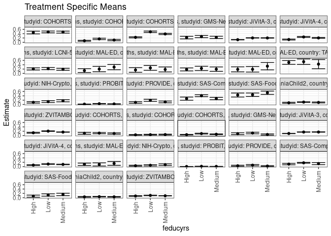

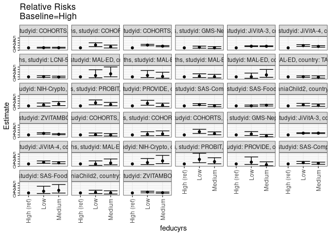

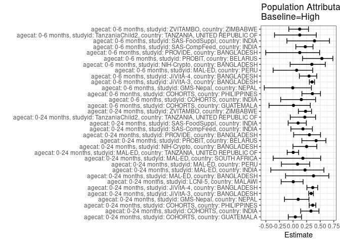

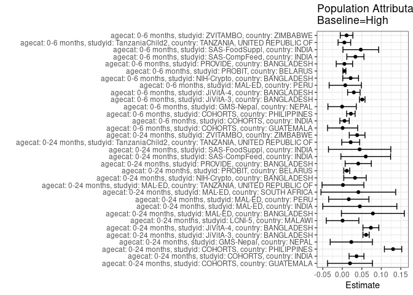

## Results Table

### Parameter: TSM

| agecat | studyid | country | intervention_level | baseline_level | estimate | ci_lower | ci_upper |
| --- | --- | --- | --- | --- | --- | --- | --- |
| 0-24 months | COHORTS | GUATEMALA | High | NA | 0.4529915 | 0.3891863 | 0.5167966 |
| 0-24 months | COHORTS | GUATEMALA | Low | NA | 0.4814815 | 0.4403379 | 0.5226251 |
| 0-24 months | COHORTS | GUATEMALA | Medium | NA | 0.4721604 | 0.4259654 | 0.5183553 |
| 0-24 months | COHORTS | INDIA | High | NA | 0.0740741 | 0.0525101 | 0.0956380 |
| 0-24 months | COHORTS | INDIA | Low | NA | 0.1588983 | 0.1259061 | 0.1918905 |
| 0-24 months | COHORTS | INDIA | Medium | NA | 0.1053922 | 0.0755872 | 0.1351971 |
| 0-24 months | COHORTS | PHILIPPINES | High | NA | 0.2298739 | 0.2041865 | 0.2555613 |
| 0-24 months | COHORTS | PHILIPPINES | Low | NA | 0.4879227 | 0.4538700 | 0.5219754 |
| 0-24 months | COHORTS | PHILIPPINES | Medium | NA | 0.3878550 | 0.3579618 | 0.4177482 |
| 0-24 months | GMS-Nepal | NEPAL | High | NA | 0.2196532 | 0.1579156 | 0.2813908 |
| 0-24 months | GMS-Nepal | NEPAL | Low | NA | 0.2668919 | 0.2164645 | 0.3173192 |
| 0-24 months | GMS-Nepal | NEPAL | Medium | NA | 0.2290749 | 0.1743680 | 0.2837818 |
| 0-24 months | JiVitA-3 | BANGLADESH | High | NA | 0.1219250 | 0.1129626 | 0.1308874 |
| 0-24 months | JiVitA-3 | BANGLADESH | Low | NA | 0.2036161 | 0.1956826 | 0.2115497 |
| 0-24 months | JiVitA-3 | BANGLADESH | Medium | NA | 0.2021467 | 0.1925534 | 0.2117400 |
| 0-24 months | JiVitA-4 | BANGLADESH | High | NA | 0.1291099 | 0.1072339 | 0.1509858 |
| 0-24 months | JiVitA-4 | BANGLADESH | Low | NA | 0.2478239 | 0.2258198 | 0.2698279 |
| 0-24 months | JiVitA-4 | BANGLADESH | Medium | NA | 0.2037572 | 0.1836939 | 0.2238205 |
| 0-24 months | LCNI-5 | MALAWI | High | NA | 0.2071713 | 0.1570026 | 0.2573400 |
| 0-24 months | LCNI-5 | MALAWI | Low | NA | 0.2233677 | 0.1754841 | 0.2712513 |
| 0-24 months | LCNI-5 | MALAWI | Medium | NA | 0.1918819 | 0.1449698 | 0.2387940 |
| 0-24 months | MAL-ED | BANGLADESH | High | NA | 0.1296296 | 0.0397383 | 0.2195209 |
| 0-24 months | MAL-ED | BANGLADESH | Low | NA | 0.2000000 | 0.0756229 | 0.3243771 |
| 0-24 months | MAL-ED | BANGLADESH | Medium | NA | 0.2909091 | 0.1704725 | 0.4113457 |
| 0-24 months | MAL-ED | INDIA | High | NA | 0.1590909 | 0.0506480 | 0.2675338 |
| 0-24 months | MAL-ED | INDIA | Low | NA | 0.2542373 | 0.1427503 | 0.3657243 |
| 0-24 months | MAL-ED | INDIA | Medium | NA | 0.1818182 | 0.0674652 | 0.2961712 |
| 0-24 months | MAL-ED | PERU | High | NA | 0.1833333 | 0.1139635 | 0.2527032 |
| 0-24 months | MAL-ED | PERU | Low | NA | 0.2318841 | 0.1321042 | 0.3316639 |
| 0-24 months | MAL-ED | PERU | Medium | NA | 0.1967213 | 0.0967645 | 0.2966781 |

[output cut: 69 more lines]

### Parameter: E(Y)

| agecat | studyid | country | intervention_level | baseline_level | estimate | ci_lower | ci_upper |
| --- | --- | --- | --- | --- | --- | --- | --- |
| 0-24 months | COHORTS | GUATEMALA | NA | NA | 0.4728000 | 0.4451119 | 0.5004881 |
| 0-24 months | COHORTS | INDIA | NA | NA | 0.1105736 | 0.0944098 | 0.1267374 |
| 0-24 months | COHORTS | PHILIPPINES | NA | NA | 0.3600694 | 0.3425352 | 0.3776037 |
| 0-24 months | GMS-Nepal | NEPAL | NA | NA | 0.2428161 | 0.2109378 | 0.2746944 |
| 0-24 months | JiVitA-3 | BANGLADESH | NA | NA | 0.1828613 | 0.1771578 | 0.1885648 |
| 0-24 months | JiVitA-4 | BANGLADESH | NA | NA | 0.2024261 | 0.1900868 | 0.2147654 |
| 0-24 months | LCNI-5 | MALAWI | NA | NA | 0.2078721 | 0.1799617 | 0.2357825 |
| 0-24 months | MAL-ED | BANGLADESH | NA | NA | 0.2080537 | 0.1426574 | 0.2734499 |
| 0-24 months | MAL-ED | INDIA | NA | NA | 0.2040816 | 0.1387072 | 0.2694561 |
| 0-24 months | MAL-ED | PERU | NA | NA | 0.2000000 | 0.1503169 | 0.2496831 |
| 0-24 months | MAL-ED | SOUTH AFRICA | NA | NA | 0.2272727 | 0.1486005 | 0.3059450 |
| 0-24 months | MAL-ED | TANZANIA, UNITED REPUBLIC OF | NA | NA | 0.5094340 | 0.4419812 | 0.5768867 |
| 0-24 months | NIH-Crypto | BANGLADESH | NA | NA | 0.1306069 | 0.1066024 | 0.1546113 |
| 0-24 months | PROBIT | BELARUS | NA | NA | 0.0269707 | 0.0195564 | 0.0343850 |
| 0-24 months | PROVIDE | BANGLADESH | NA | NA | 0.1357143 | 0.1103250 | 0.1611036 |
| 0-24 months | SAS-CompFeed | INDIA | NA | NA | 0.3300654 | 0.3020915 | 0.3580392 |
| 0-24 months | SAS-FoodSuppl | INDIA | NA | NA | 0.4808612 | 0.4329065 | 0.5288160 |
| 0-24 months | TanzaniaChild2 | TANZANIA, UNITED REPUBLIC OF | NA | NA | 0.0994545 | 0.0874362 | 0.1114727 |
| 0-24 months | ZVITAMBO | ZIMBABWE | NA | NA | 0.1660581 | 0.1598251 | 0.1722911 |
| 0-6 months | COHORTS | GUATEMALA | NA | NA | 0.1039216 | 0.0851851 | 0.1226580 |
| 0-6 months | COHORTS | INDIA | NA | NA | 0.0380014 | 0.0280567 | 0.0479461 |
| 0-6 months | COHORTS | PHILIPPINES | NA | NA | 0.0618056 | 0.0530095 | 0.0706016 |
| 0-6 months | GMS-Nepal | NEPAL | NA | NA | 0.0862069 | 0.0653403 | 0.1070734 |
| 0-6 months | JiVitA-3 | BANGLADESH | NA | NA | 0.1460777 | 0.1409301 | 0.1512254 |
| 0-6 months | JiVitA-4 | BANGLADESH | NA | NA | 0.1008032 | 0.0917342 | 0.1098723 |
| 0-6 months | MAL-ED | PERU | NA | NA | 0.1160000 | 0.0762256 | 0.1557744 |
| 0-6 months | NIH-Crypto | BANGLADESH | NA | NA | 0.0620053 | 0.0448256 | 0.0791849 |
| 0-6 months | PROBIT | BELARUS | NA | NA | 0.0102397 | 0.0068687 | 0.0136108 |
| 0-6 months | PROVIDE | BANGLADESH | NA | NA | 0.0442857 | 0.0290345 | 0.0595370 |
| 0-6 months | SAS-CompFeed | INDIA | NA | NA | 0.1493124 | 0.1303783 | 0.1682465 |
| 0-6 months | SAS-FoodSuppl | INDIA | NA | NA | 0.1201923 | 0.0889059 | 0.1514788 |
| 0-6 months | TanzaniaChild2 | TANZANIA, UNITED REPUBLIC OF | NA | NA | 0.0432228 | 0.0350563 | 0.0513894 |
| 0-6 months | ZVITAMBO | ZIMBABWE | NA | NA | 0.0901382 | 0.0853389 | 0.0949375 |

### Parameter: RR

| agecat | studyid | country | intervention_level | baseline_level | estimate | ci_lower | ci_upper |
| --- | --- | --- | --- | --- | --- | --- | --- |
| 0-24 months | COHORTS | GUATEMALA | High | High | 1.0000000 | 1.0000000 | 1.000000 |
| 0-24 months | COHORTS | GUATEMALA | Low | High | 1.0628931 | 0.9014483 | 1.253252 |
| 0-24 months | COHORTS | GUATEMALA | Medium | High | 1.0423163 | 0.8780489 | 1.237315 |
| 0-24 months | COHORTS | INDIA | High | High | 1.0000000 | 1.0000000 | 1.000000 |
| 0-24 months | COHORTS | INDIA | Low | High | 2.1451271 | 1.5002433 | 3.067216 |
| 0-24 months | COHORTS | INDIA | Medium | High | 1.4227941 | 0.9481542 | 2.135036 |
| 0-24 months | COHORTS | PHILIPPINES | High | High | 1.0000000 | 1.0000000 | 1.000000 |
| 0-24 months | COHORTS | PHILIPPINES | Low | High | 2.1225667 | 1.8605586 | 2.421471 |
| 0-24 months | COHORTS | PHILIPPINES | Medium | High | 1.6872513 | 1.4730770 | 1.932565 |
| 0-24 months | GMS-Nepal | NEPAL | High | High | 1.0000000 | 1.0000000 | 1.000000 |
| 0-24 months | GMS-Nepal | NEPAL | Low | High | 1.2150605 | 0.8659929 | 1.704832 |
| 0-24 months | GMS-Nepal | NEPAL | Medium | High | 1.0428936 | 0.7212082 | 1.508062 |
| 0-24 months | JiVitA-3 | BANGLADESH | High | High | 1.0000000 | 1.0000000 | 1.000000 |
| 0-24 months | JiVitA-3 | BANGLADESH | Low | High | 1.6700118 | 1.5405848 | 1.810312 |
| 0-24 months | JiVitA-3 | BANGLADESH | Medium | High | 1.6579597 | 1.5221158 | 1.805927 |
| 0-24 months | JiVitA-4 | BANGLADESH | High | High | 1.0000000 | 1.0000000 | 1.000000 |
| 0-24 months | JiVitA-4 | BANGLADESH | Low | High | 1.9194805 | 1.5832299 | 2.327145 |
| 0-24 months | JiVitA-4 | BANGLADESH | Medium | High | 1.5781693 | 1.2949494 | 1.923332 |
| 0-24 months | LCNI-5 | MALAWI | High | High | 1.0000000 | 1.0000000 | 1.000000 |
| 0-24 months | LCNI-5 | MALAWI | Low | High | 1.0781787 | 0.7802500 | 1.489868 |
| 0-24 months | LCNI-5 | MALAWI | Medium | High | 0.9261993 | 0.6565347 | 1.306626 |
| 0-24 months | MAL-ED | BANGLADESH | High | High | 1.0000000 | 1.0000000 | 1.000000 |
| 0-24 months | MAL-ED | BANGLADESH | Low | High | 1.5428571 | 0.6078543 | 3.916084 |
| 0-24 months | MAL-ED | BANGLADESH | Medium | High | 2.2441558 | 1.0006999 | 5.032713 |
| 0-24 months | MAL-ED | INDIA | High | High | 1.0000000 | 1.0000000 | 1.000000 |
| 0-24 months | MAL-ED | INDIA | Low | High | 1.5980630 | 0.7105469 | 3.594140 |
| 0-24 months | MAL-ED | INDIA | Medium | High | 1.1428571 | 0.4520604 | 2.889265 |
| 0-24 months | MAL-ED | PERU | High | High | 1.0000000 | 1.0000000 | 1.000000 |
| 0-24 months | MAL-ED | PERU | Low | High | 1.2648221 | 0.7131453 | 2.243266 |
| 0-24 months | MAL-ED | PERU | Medium | High | 1.0730253 | 0.5694745 | 2.021835 |

[output cut: 69 more lines]

### Parameter: PAR

| agecat | studyid | country | intervention_level | baseline_level | estimate | ci_lower | ci_upper |
| --- | --- | --- | --- | --- | --- | --- | --- |
| 0-24 months | COHORTS | GUATEMALA | High | NA | 0.0198085 | -0.0377546 | 0.0773717 |
| 0-24 months | COHORTS | INDIA | High | NA | 0.0364995 | 0.0174771 | 0.0555220 |
| 0-24 months | COHORTS | PHILIPPINES | High | NA | 0.1301955 | 0.1079500 | 0.1524410 |
| 0-24 months | GMS-Nepal | NEPAL | High | NA | 0.0231629 | -0.0309938 | 0.0773196 |
| 0-24 months | JiVitA-3 | BANGLADESH | High | NA | 0.0609363 | 0.0529413 | 0.0689313 |
| 0-24 months | JiVitA-4 | BANGLADESH | High | NA | 0.0733162 | 0.0530113 | 0.0936211 |
| 0-24 months | LCNI-5 | MALAWI | High | NA | 0.0007008 | -0.0410340 | 0.0424355 |
| 0-24 months | MAL-ED | BANGLADESH | High | NA | 0.0784241 | -0.0021994 | 0.1590476 |
| 0-24 months | MAL-ED | INDIA | High | NA | 0.0449907 | -0.0498447 | 0.1398262 |
| 0-24 months | MAL-ED | PERU | High | NA | 0.0166667 | -0.0349172 | 0.0682505 |
| 0-24 months | MAL-ED | SOUTH AFRICA | High | NA | 0.0412262 | -0.0545238 | 0.1369763 |
| 0-24 months | MAL-ED | TANZANIA, UNITED REPUBLIC OF | High | NA | 0.0017417 | -0.0518281 | 0.0553114 |
| 0-24 months | NIH-Crypto | BANGLADESH | High | NA | 0.0326339 | 0.0038639 | 0.0614039 |
| 0-24 months | PROBIT | BELARUS | High | NA | 0.0114554 | 0.0038651 | 0.0190456 |
| 0-24 months | PROVIDE | BANGLADESH | High | NA | 0.0408867 | 0.0073536 | 0.0744198 |
| 0-24 months | SAS-CompFeed | INDIA | High | NA | 0.0601425 | -0.0035938 | 0.1238787 |
| 0-24 months | SAS-FoodSuppl | INDIA | High | NA | 0.0444976 | -0.0353646 | 0.1243598 |
| 0-24 months | TanzaniaChild2 | TANZANIA, UNITED REPUBLIC OF | High | NA | 0.0215035 | -0.0014705 | 0.0444774 |
| 0-24 months | ZVITAMBO | ZIMBABWE | High | NA | 0.0380581 | 0.0179329 | 0.0581833 |
| 0-6 months | COHORTS | GUATEMALA | High | NA | 0.0008288 | -0.0377279 | 0.0393855 |
| 0-6 months | COHORTS | INDIA | High | NA | 0.0058010 | -0.0062237 | 0.0178258 |
| 0-6 months | COHORTS | PHILIPPINES | High | NA | 0.0220383 | 0.0111850 | 0.0328917 |
| 0-6 months | GMS-Nepal | NEPAL | High | NA | -0.0004983 | -0.0368427 | 0.0358461 |
| 0-6 months | JiVitA-3 | BANGLADESH | High | NA | 0.0511410 | 0.0440786 | 0.0582034 |
| 0-6 months | JiVitA-4 | BANGLADESH | High | NA | 0.0296770 | 0.0136944 | 0.0456597 |
| 0-6 months | MAL-ED | PERU | High | NA | 0.0076667 | -0.0336394 | 0.0489727 |
| 0-6 months | NIH-Crypto | BANGLADESH | High | NA | 0.0214647 | 0.0013193 | 0.0416101 |
| 0-6 months | PROBIT | BELARUS | High | NA | 0.0054374 | 0.0016656 | 0.0092092 |
| 0-6 months | PROVIDE | BANGLADESH | High | NA | 0.0054926 | -0.0155087 | 0.0264940 |
| 0-6 months | SAS-CompFeed | INDIA | High | NA | 0.0336311 | 0.0117066 | 0.0555557 |
| 0-6 months | SAS-FoodSuppl | INDIA | High | NA | 0.0474650 | 0.0017362 | 0.0931939 |
| 0-6 months | TanzaniaChild2 | TANZANIA, UNITED REPUBLIC OF | High | NA | 0.0053609 | -0.0107944 | 0.0215162 |
| 0-6 months | ZVITAMBO | ZIMBABWE | High | NA | 0.0109799 | -0.0052277 | 0.0271874 |

### Parameter: PAF

| agecat | studyid | country | intervention_level | baseline_level | estimate | ci_lower | ci_upper |
| --- | --- | --- | --- | --- | --- | --- | --- |
| 0-24 months | COHORTS | GUATEMALA | High | NA | 0.0418963 | -0.0879472 | 0.1562433 |
| 0-24 months | COHORTS | INDIA | High | NA | 0.3300926 | 0.1413331 | 0.4773573 |
| 0-24 months | COHORTS | PHILIPPINES | High | NA | 0.3615845 | 0.2974975 | 0.4198251 |
| 0-24 months | GMS-Nepal | NEPAL | High | NA | 0.0953928 | -0.1573555 | 0.2929449 |
| 0-24 months | JiVitA-3 | BANGLADESH | High | NA | 0.3332379 | 0.2886982 | 0.3749887 |
| 0-24 months | JiVitA-4 | BANGLADESH | High | NA | 0.3621876 | 0.2551617 | 0.4538349 |
| 0-24 months | LCNI-5 | MALAWI | High | NA | 0.0033711 | -0.2190518 | 0.1852117 |
| 0-24 months | MAL-ED | BANGLADESH | High | NA | 0.3769415 | -0.1376520 | 0.6587692 |
| 0-24 months | MAL-ED | INDIA | High | NA | 0.2204545 | -0.4090534 | 0.5687239 |
| 0-24 months | MAL-ED | PERU | High | NA | 0.0833333 | -0.2139309 | 0.3078043 |
| 0-24 months | MAL-ED | SOUTH AFRICA | High | NA | 0.1813953 | -0.3655131 | 0.5092588 |
| 0-24 months | MAL-ED | TANZANIA, UNITED REPUBLIC OF | High | NA | 0.0034188 | -0.1074860 | 0.1032175 |
| 0-24 months | NIH-Crypto | BANGLADESH | High | NA | 0.2498635 | -0.0011679 | 0.4379517 |
| 0-24 months | PROBIT | BELARUS | High | NA | 0.4247339 | 0.1623246 | 0.6049411 |
| 0-24 months | PROVIDE | BANGLADESH | High | NA | 0.3012704 | 0.0120515 | 0.5058214 |
| 0-24 months | SAS-CompFeed | INDIA | High | NA | 0.1822139 | -0.0392680 | 0.3564950 |
| 0-24 months | SAS-FoodSuppl | INDIA | High | NA | 0.0925373 | -0.0899230 | 0.2444525 |
| 0-24 months | TanzaniaChild2 | TANZANIA, UNITED REPUBLIC OF | High | NA | 0.2162142 | -0.0507880 | 0.4153719 |
| 0-24 months | ZVITAMBO | ZIMBABWE | High | NA | 0.2291856 | 0.0981925 | 0.3411511 |
| 0-6 months | COHORTS | GUATEMALA | High | NA | 0.0079751 | -0.4419424 | 0.3175085 |
| 0-6 months | COHORTS | INDIA | High | NA | 0.1526535 | -0.2275263 | 0.4150870 |
| 0-6 months | COHORTS | PHILIPPINES | High | NA | 0.3565754 | 0.1636143 | 0.5050188 |
| 0-6 months | GMS-Nepal | NEPAL | High | NA | -0.0057803 | -0.5294892 | 0.3386066 |
| 0-6 months | JiVitA-3 | BANGLADESH | High | NA | 0.3500945 | 0.3008924 | 0.3958339 |
| 0-6 months | JiVitA-4 | BANGLADESH | High | NA | 0.2944058 | 0.1162005 | 0.4366785 |
| 0-6 months | MAL-ED | PERU | High | NA | 0.0660920 | -0.3666002 | 0.3617854 |
| 0-6 months | NIH-Crypto | BANGLADESH | High | NA | 0.3461760 | -0.0531765 | 0.5940985 |
| 0-6 months | PROBIT | BELARUS | High | NA | 0.5310073 | 0.1751252 | 0.7333484 |
| 0-6 months | PROVIDE | BANGLADESH | High | NA | 0.1240267 | -0.5021944 | 0.4891945 |
| 0-6 months | SAS-CompFeed | INDIA | High | NA | 0.2252402 | 0.0510766 | 0.3674381 |
| 0-6 months | SAS-FoodSuppl | INDIA | High | NA | 0.3949091 | -0.1128652 | 0.6709979 |
| 0-6 months | TanzaniaChild2 | TANZANIA, UNITED REPUBLIC OF | High | NA | 0.1240297 | -0.3411048 | 0.4278419 |
| 0-6 months | ZVITAMBO | ZIMBABWE | High | NA | 0.1218113 | -0.0776088 | 0.2843272 |